# Error_HT-SELEX

Florian Curvaia

5/31/2022

Warning: This file cannot be run in one single time, because it first create files which then need to be used by the python script Comparison_SELEX.py to generate the files needed for the rest of the code to run.

Chunk which generates the files needed for the python script Comparison_SELEX.py:

# PROX1

Generation of the comparison file with python

```
   Genotype          Score_nomet       Score_met        Difference
 Length:649         Min.   :-8.869   Min.   :-9.327   Min.   :-2.5476
 Class :character   1st Qu.:-8.417   1st Qu.:-8.827   1st Qu.:-0.9159
 Mode  :character   Median :-7.934   Median :-8.277   Median :-0.3981
                    Mean   :-7.743   Mean   :-8.119   Mean   :-0.3757
                    3rd Qu.:-7.299   3rd Qu.:-7.574   3rd Qu.: 0.1288
                    Max.   :-4.434   Max.   :-4.902   Max.   : 2.7120
 Contains_CpG
 False: 70
 True :579
```

Plot with both sequences having CpG and sequences not having CpG

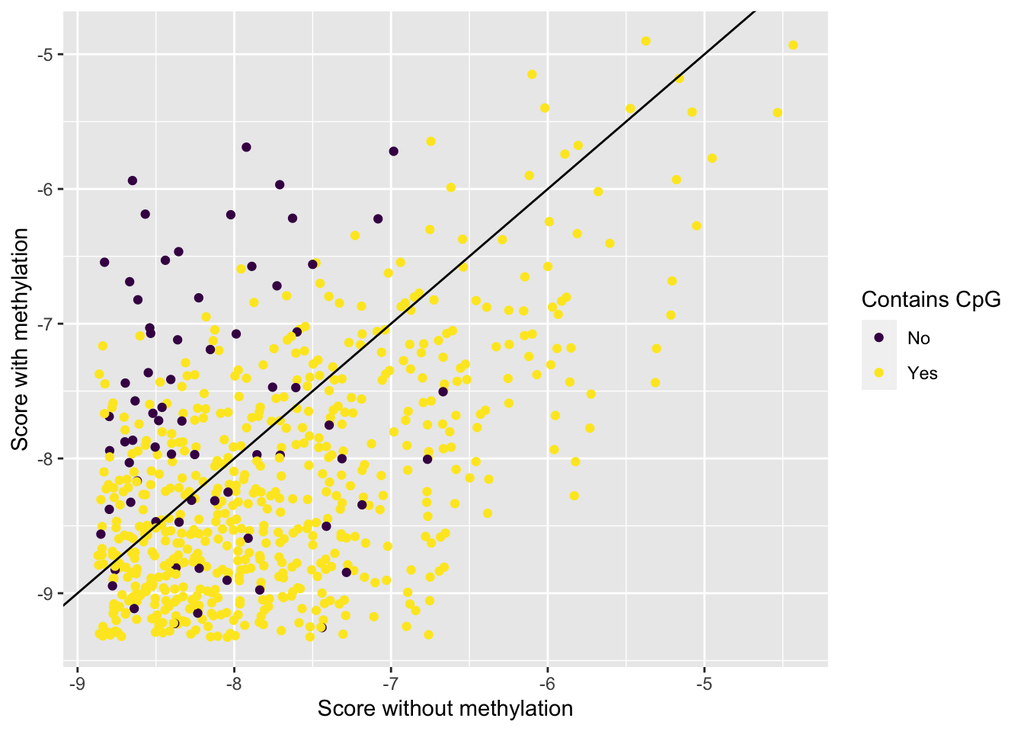

```r
ggplot(PROX1, aes(x=Score_nomet, y=Score_met, color=Contains_CpG))+geom_point()+geom_abline(slope=1, intercept = 0) + scale_color_viridis(discrete=TRUE, name="Contains CpG", labels=c("No","Yes"))+xlab("Score without methylation")+ylab("Score with methylation")
```

```r
ggsave(paste(path, "PROX1_scatter.png", sep="/"))
```

Plot with sequences having CpG

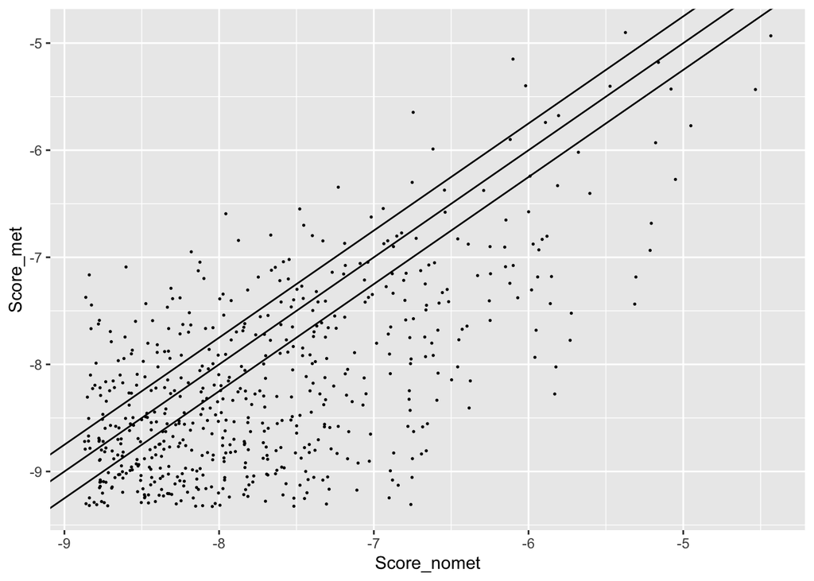

```r
PROX1_CG <- PROX1[PROX1$Contains_CpG == "True",]
PROX1_no_CG <- PROX1[PROX1$Contains_CpG == "False",]
ggplot(PROX1_CG, aes(x=Score_nomet, y=Score_met))+geom_point(size=0.25)+geom_abline(slope=1, intercept = 0) + geom_abline(slope=1, intercept = 0.25) + geom_abline(slope=1, intercept = -0.25)
```

Plot with sequences not having CpG

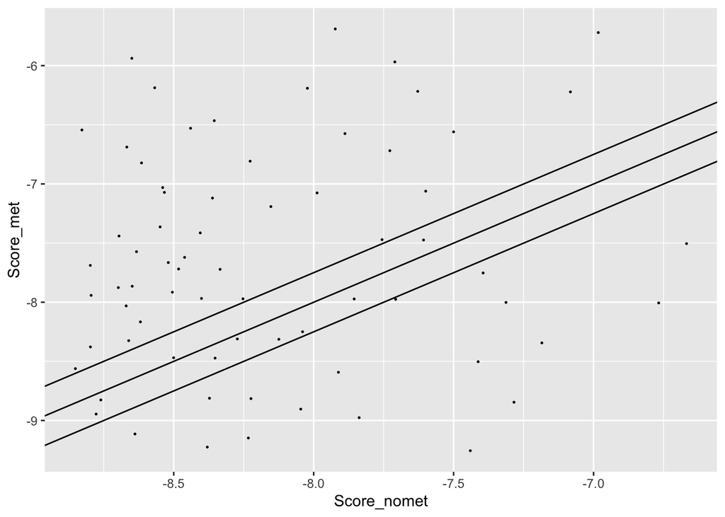

```r
ggplot(PROX1_no_CG, aes(x=Score_nomet, y=Score_met))+geom_point(size=0.25)+geom_abline(slope=1, intercept = 0) + geom_abline(slope=1, intercept = 0.25) + geom_abline(slope=1, intercept = -0.25)
```

Violin plot of distribution of the scores between methylated and non methylated sequences.

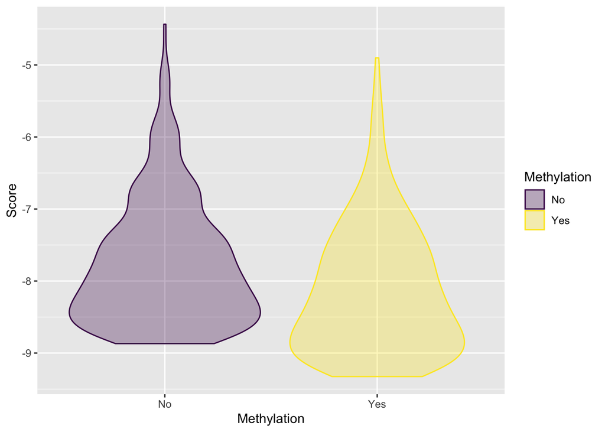

```r
PROX1_mod <- melt(PROX1, measure.vars = c('Score_nomet', 'Score_met'), variable.name="Methylation")
levels(PROX1_mod$Methylation) <- c("No", "Yes")
ggplot(data=PROX1_mod)+geom_violin(aes(Methylation, value, color=Methylation, fill=Methylation))+scale_color_viridis(discrete=TRUE)+scale_fill_viridis(discrete = TRUE, alpha=0.3)+ylab("Score")
```

```r
ggsave(paste(path, "PROX1_violin.png", sep="/"))
```

Are the non-methylated scores normally distributed ?

```r
shapiro.test(PROX1$Score_nomet)
```

```
    Shapiro-Wilk normality test

data:  PROX1$Score_nomet
W = 0.92288, p-value < 2.2e-16
```

P-value<<0.05, so we reject the null hypothesis of normal distribution

Are the methylated scores normally distributed ?

```r
shapiro.test(PROX1$Score_met)
```

```
    Shapiro-Wilk normality test

data:  PROX1$Score_met
W = 0.93471, p-value = 3.089e-16
```

P-value<<0.05, so we reject the null hyptohesis of normal distribution

Is there a change between non-methylated and methylated sequences

```r
wilcox.test(PROX1$Score_nomet, PROX1$Score_met, paired=TRUE)
```

```
    Wilcoxon signed rank test with continuity correction

data:  PROX1$Score_nomet and PROX1$Score_met
V = 156725, p-value < 2.2e-16
alternative hypothesis: true location shift is not equal to 0
```

Rejection of null hypothesis of no difference between not methylated and methylated sequences.

Are the scores of methylated sequences greater than the one of non-methylated sequences ?

```r
wilcox.test(PROX1$Score_nomet, PROX1$Score_met, paired=TRUE, alternative="less")
```

```
    Wilcoxon signed rank test with continuity correction

data:  PROX1$Score_nomet and PROX1$Score_met
V = 156725, p-value = 1
alternative hypothesis: true location shift is less than 0
```

Are the scores of methylated sequences smaller than the one of non-methylated sequences ?

```r
wilcox.test(PROX1$Score_nomet, PROX1$Score_met, paired=TRUE, alternative="greater")
```

```
    Wilcoxon signed rank test with continuity correction

data:  PROX1$Score_nomet and PROX1$Score_met
V = 156725, p-value < 2.2e-16
alternative hypothesis: true location shift is greater than 0
```

The results are not really consistent with landscapes’ results. Let’s try to filter the data by only looking at the sequences which contain at least on CpG dinucleotide.

First, is the scores of methylated sequences greater than the one of non-methylated sequences ?

```
    Wilcoxon signed rank test with continuity correction

data:  PROX1_CG$Score_nomet and PROX1_CG$Score_met
V = 136360, p-value = 1
alternative hypothesis: true location shift is less than 0
```

Then, is the scores of methylated sequences smaller than the one of non-methylated sequences ?

```
    Wilcoxon signed rank test with continuity correction

data:  PROX1_CG$Score_nomet and PROX1_CG$Score_met
V = 136360, p-value < 2.2e-16
alternative hypothesis: true location shift is greater than 0
```

Analyse spread of the scores of sequences which doesn’t contain any CpG:

```r
quantile(PROX1_no_CG$Difference, probs = seq(.1, .9, by = .1))
```

```
       10%        20%        30%        40%        50%        60%        70%
-0.8633180 -0.4467928 -0.1181132  0.2877485  0.6008348  0.8537409  1.0243097
       80%        90%
 1.3331853  1.8370572
```

```r
quantile(PROX1_no_CG$Difference, probs = seq(.05, .95, by = .05))
```

```
         5%         10%         15%         20%         25%         30%
-1.15001290 -0.86331804 -0.68594842 -0.44679278 -0.20475902 -0.11811317
        35%         40%         45%         50%         55%         60%
 0.04633302  0.28774845  0.43383131  0.60083481  0.78246898  0.85374091
        65%         70%         75%         80%         85%         90%
 0.93603461  1.02430973  1.22789176  1.33318534  1.49233303  1.83705715
        95%
 2.11887016
```

Let’s try with absolute difference:

```r
quantile(abs(PROX1_no_CG$Difference), probs = seq(.1, .9, by = .1))
```

```
      10%       20%       30%       40%       50%       60%       70%       80%
0.1870396 0.3536064 0.5741409 0.7755261 0.8561162 0.9983827 1.2013689 1.4277224
      90%
1.8370572
```

```r
quantile(abs(PROX1_no_CG$Difference), probs = seq(.05, .95, by = .05))
```

```
       5%       10%       15%       20%       25%       30%       35%       40%
0.1186069 0.1870396 0.2825911 0.3536064 0.4428775 0.5741409 0.6450259 0.7755261
      45%       50%       55%       60%       65%       70%       75%       80%
0.8404503 0.8561162 0.9142826 0.9983827 1.1065386 1.2013689 1.2608263 1.4277224
      85%       90%       95%
1.6785245 1.8370572 2.1188702
```

Let’s compute the proportion of sequences containing no CpG with a difference inside the 0.25 deviation bound used for now:

```r
dev_PROX1 <- PROX1_no_CG[abs(PROX1_no_CG$Difference)<=0.25,]
nrow(dev_PROX1)/nrow(PROX1_no_CG)
```

```
[1] 0.1285714
```

Then let’s see if there is a difference in the effect of methylation between sequences with at least one CpG and sequences without any:

```r
shapiro.test(PROX1_no_CG$Difference)
```

```
    Shapiro-Wilk normality test

data:  PROX1_no_CG$Difference
W = 0.98823, p-value = 0.7581
```

```r
wilcox.test(PROX1_no_CG$Difference, PROX1_CG$Difference)
```

```
    Wilcoxon rank sum test with continuity correction

data:  PROX1_no_CG$Difference and PROX1_CG$Difference
W = 31215, p-value = 1.469e-13
alternative hypothesis: true location shift is not equal to 0
```

# PROP1

Generation of the comparison file with python

```
   Genotype          Score_nomet        Score_met         Difference
 Length:497         Min.   :-10.679   Min.   :-13.543   Min.   :-3.9261
 Class :character   1st Qu.: -9.818   1st Qu.:-10.100   1st Qu.:-1.2098
 Mode  :character   Median : -8.526   Median : -8.638   Median :-0.1387
                    Mean   : -8.332   Mean   : -8.506   Mean   :-0.1747
                    3rd Qu.: -7.415   3rd Qu.: -6.988   3rd Qu.: 0.8183
                    Max.   : -2.540   Max.   : -2.738   Max.   : 2.9933
 Contains_CpG
 False:372
 True :125
```

Plot with both sequences having CpG and sequences not having CpG

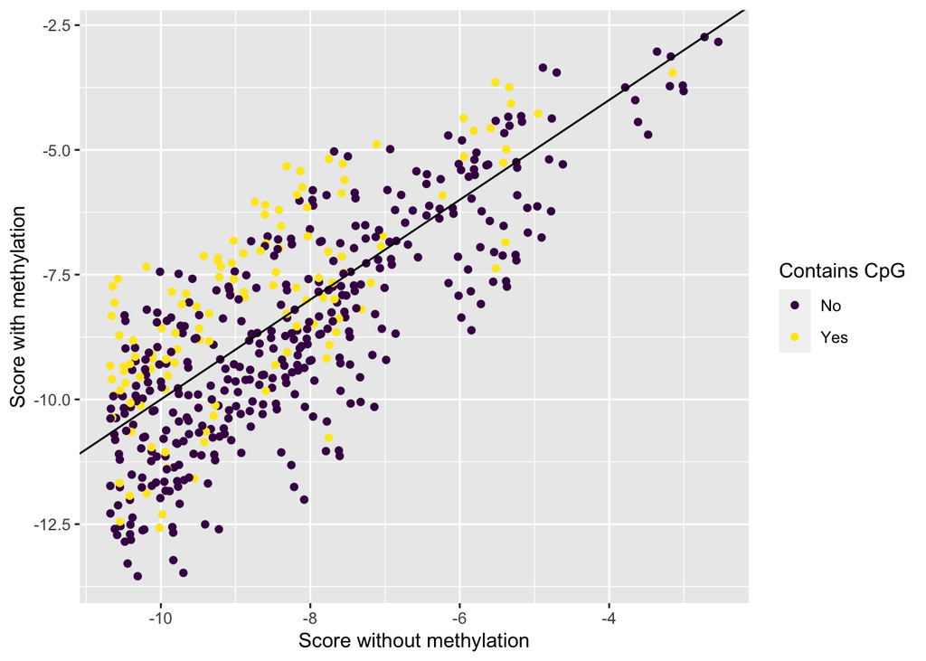

```r
ggplot(PROP1, aes(x=Score_nomet, y=Score_met, color=Contains_CpG))+geom_point()+geom_abline(slope=1, intercept = 0) + scale_color_viridis(discrete=TRUE, name="Contains CpG", labels=c("No","Yes"))+xlab("Score without methylation")+ylab("Score with methylation")
```

```r
ggsave(paste(path, "PROP1_scatter.png", sep="/"))
```

Plot with sequences having CpG

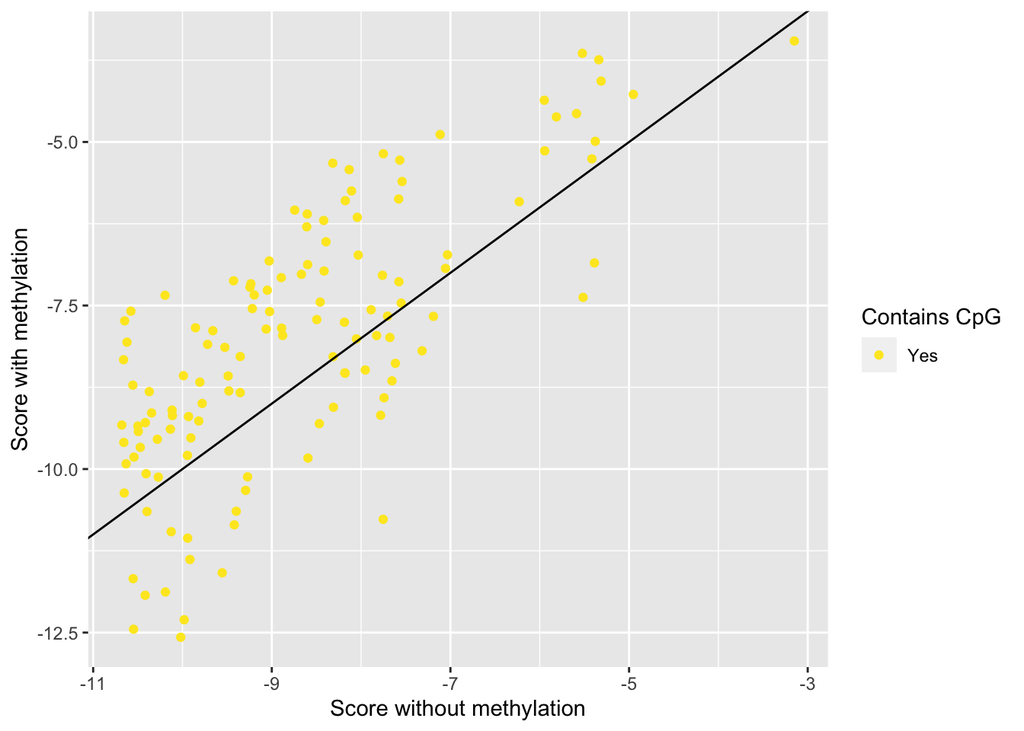

```r
PROP1_CG <- PROP1[PROP1$Contains_CpG == "True",]
PROP1_no_CG <- PROP1[PROP1$Contains_CpG == "False",]
ggplot(PROP1_CG, aes(x=Score_nomet, y=Score_met, color=Contains_CpG))+geom_point()+geom_abline(slope=1, intercept = 0) + scale_color_viridis(discrete=TRUE, name="Contains CpG", labels=c("Yes","No"), direction=-1)+xlab("Score without methylation")+ylab("Score with methylation")
```

```r
ggsave(paste(path, "PROP1_scatter_CG.png", sep="/"))
summary(PROP1_CG)
```

```
   Genotype          Score_nomet        Score_met         Difference
 Length:125         Min.   :-10.679   Min.   :-12.571   Min.   :-3.0158
 Class :character   1st Qu.: -9.981   1st Qu.: -9.306   1st Qu.:-0.2523
 Mode  :character   Median : -8.894   Median : -7.989   Median : 0.8039
                    Mean   : -8.694   Mean   : -8.025   Mean   : 0.6692
                    3rd Qu.: -7.761   3rd Qu.: -6.875   3rd Qu.: 1.7078
                    Max.   : -3.150   Max.   : -3.456   Max.   : 2.9933
 Contains_CpG
 False:  0
 True :125
```

Plot with sequences not having CpG

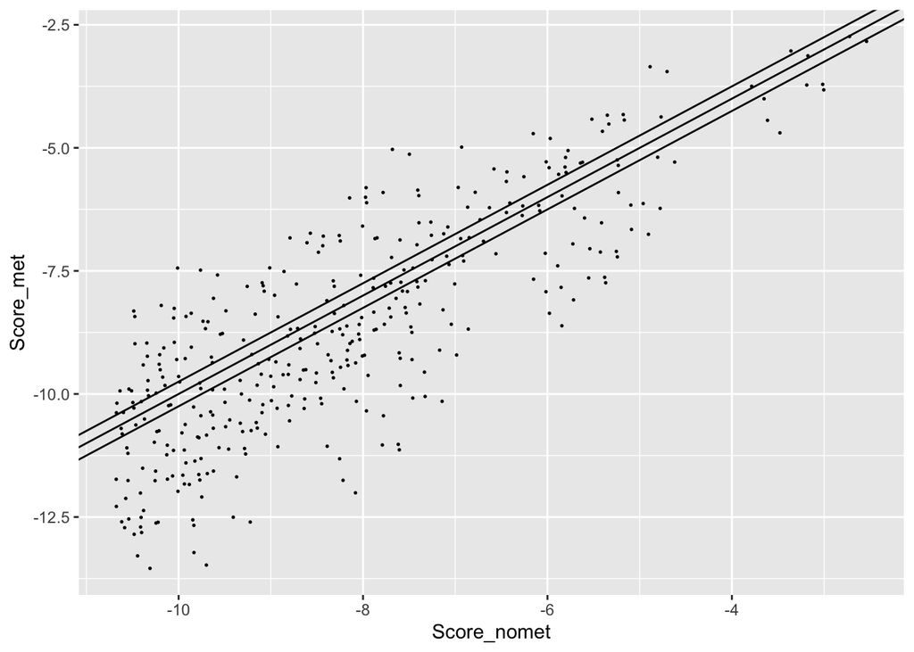

```r
ggplot(PROP1_no_CG, aes(x=Score_nomet, y=Score_met))+geom_point(size=0.25)+geom_abline(slope=1, intercept = 0) + geom_abline(slope=1, intercept = 0.25) + geom_abline(slope=1, intercept = -0.25)
```

Violin plot of distribution of the scores between methylated and non methylated sequences.

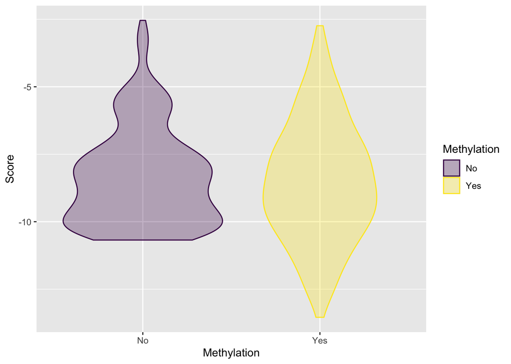

```r
PROP1_mod <- melt(PROP1, measure.vars = c('Score_nomet', 'Score_met'), variable.name="Methylation")
levels(PROP1_mod$Methylation) <- c("No", "Yes")
ggplot(data=PROP1_mod)+geom_violin(aes(Methylation, value, color=Methylation, fill=Methylation))+scale_color_viridis(discrete=TRUE)+scale_fill_viridis(discrete = TRUE, alpha=0.3)+ylab("Score")
```

```r
ggsave(paste(path, "PROP1_violin.png", sep="/"))
```

Violin plot of distribution of the scores between methylated and non methylated sequences that contains CG.

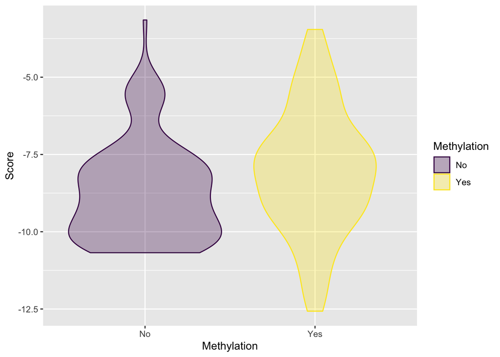

```r
PROP1_CG_mod <- melt(PROP1_CG, measure.vars = c('Score_nomet', 'Score_met'), variable.name="Methylation")
levels(PROP1_CG_mod$Methylation) <- c("No", "Yes")
ggplot(data=PROP1_CG_mod)+geom_violin(aes(Methylation, value, color=Methylation, fill=Methylation))+scale_color_viridis(discrete=TRUE)+scale_fill_viridis(discrete = TRUE, alpha=0.3)+ylab("Score")
```

```r
ggsave(paste(path, "PROP1_CG_violin.png", sep="/"))
```

Are the non-methylated scores normally distributed ?

```r
shapiro.test(PROP1$Score_nomet)
```

```
    Shapiro-Wilk normality test

data:  PROP1$Score_nomet
W = 0.93375, p-value = 4.803e-14
```

P-value<<0.05, so we reject the null hypothesis of normal distribution

Are the methylated scores normally distributed ?

```r
shapiro.test(PROP1$Score_met)
```

```
    Shapiro-Wilk normality test

data:  PROP1$Score_met
W = 0.99208, p-value = 0.009613
```

P-value<<0.05, so we reject the null hyptohesis of normal distribution

Is there a change between non-methylated and methylated sequences

```r
wilcox.test(PROP1$Score_nomet, PROP1$Score_met, paired=TRUE)
```

```
    Wilcoxon signed rank test with continuity correction

data:  PROP1$Score_nomet and PROP1$Score_met
V = 70029, p-value = 0.01093
alternative hypothesis: true location shift is not equal to 0
```

Rejection of null hypothesis of no difference between not methylated and methylated sequences.

Are the scores of methylated sequences greater than the one of non-methylated sequences ?

```r
wilcox.test(PROP1$Score_nomet, PROP1$Score_met, paired=TRUE, alternative="less")
```

```
    Wilcoxon signed rank test with continuity correction

data:  PROP1$Score_nomet and PROP1$Score_met
V = 70029, p-value = 0.9945
alternative hypothesis: true location shift is less than 0
```

Are the scores of methylated sequences smaller than the one of non-methylated sequences ?

```r
wilcox.test(PROP1$Score_nomet, PROP1$Score_met, paired=TRUE, alternative="greater")
```

```
    Wilcoxon signed rank test with continuity correction

data:  PROP1$Score_nomet and PROP1$Score_met
V = 70029, p-value = 0.005466
alternative hypothesis: true location shift is greater than 0
```

The results are not really consistent with landscapes’ results. Let’s try to filter the data by only looking at the sequences which contain at least on CpG dinucleotide.

First, is the scores of methylated sequences greater than the one of non-methylated sequences ?

```
    Wilcoxon signed rank test with continuity correction

data:  PROP1_CG$Score_nomet and PROP1_CG$Score_met
V = 1917, p-value = 3.227e-07
alternative hypothesis: true location shift is less than 0
```

Then, is the scores of methylated sequences smaller than the one of non-methylated sequences ?

```
    Wilcoxon signed rank test with continuity correction

data:  PROP1_CG$Score_nomet and PROP1_CG$Score_met
V = 1917, p-value = 1
alternative hypothesis: true location shift is greater than 0
```

Analyse spread of the scores of sequences which doesn’t contain any CpG:

```r
quantile(PROP1_no_CG$Difference, probs = seq(.1, .9, by = .1))
```

```
       10%        20%        30%        40%        50%        60%        70%
-2.0999155 -1.5928714 -1.1928097 -0.8201099 -0.4381274 -0.1090995  0.2959798
       80%        90%
 0.7277015  1.3393583
```

```r
quantile(PROP1_no_CG$Difference, probs = seq(.05, .95, by = .05))
```

```
         5%         10%         15%         20%         25%         30%
-2.64057203 -2.09991549 -1.85053024 -1.59287141 -1.42291202 -1.19280965
        35%         40%         45%         50%         55%         60%
-1.06683176 -0.82010985 -0.67394382 -0.43812740 -0.29594280 -0.10909946
        65%         70%         75%         80%         85%         90%
 0.04652718  0.29597982  0.47583638  0.72770149  0.98433046  1.33935830
        95%
 1.61563296
```

Let’s try with absolute difference:

```r
quantile(abs(PROP1_no_CG$Difference), probs = seq(.1, .9, by = .1))
```

```
      10%       20%       30%       40%       50%       60%       70%       80%
0.2034035 0.3924215 0.5836616 0.7618143 1.0221519 1.2149440 1.5058828 1.8234270
      90%
2.2232021
```

```r
quantile(abs(PROP1_no_CG$Difference), probs = seq(.05, .95, by = .05))
```

```
        5%        10%        15%        20%        25%        30%        35%
0.08294559 0.20340346 0.29694922 0.39242154 0.46188661 0.58366161 0.69138109
       40%        45%        50%        55%        60%        65%        70%
0.76181429 0.83203230 1.02215192 1.11877260 1.21494404 1.35551409 1.50588276
       75%        80%        85%        90%        95%
1.59921652 1.82342696 1.97128101 2.22320213 2.65647939
```

Let’s compute the proportion of sequences containing no CpG with a difference inside the 0.25 deviation bound used for now:

```r
dev_PROP1 <- PROP1_no_CG[abs(PROP1_no_CG$Difference)<=0.25,]
nrow(dev_PROP1)/nrow(PROP1_no_CG)
```

```
[1] 0.1182796
```

Then let’s see if there is a difference in the effect of methylation between sequences with at least one CpG and sequences without any:

```r
shapiro.test(PROP1_no_CG$Difference)
```

```
    Shapiro-Wilk normality test

data:  PROP1_no_CG$Difference
W = 0.9947, p-value = 0.2288
```

```r
wilcox.test(PROP1_no_CG$Difference, PROP1_CG$Difference)
```

```
    Wilcoxon rank sum test with continuity correction

data:  PROP1_no_CG$Difference and PROP1_CG$Difference
W = 12658, p-value = 2.451e-14
alternative hypothesis: true location shift is not equal to 0
```